# 07.04.02.00.Problema2Cuerpos.SolucionTiempo.Sintesis

Indice | Previo: Problema2Cuerpos.SolucionTiempo.AproximacionKepler | Siguiente: Problema2Cuerpos.SolucionTiempo.VariablesUniversales

## 7.11. Una síntesis del problema de los dos cuerpos

En las secciones anteriores hemos demostrado que es posible resolver analíticamente el problema de los dos cuerpos, que podemos formular en términos generales como:

> *Dadas las posiciones y velocidades de dos partículas en un tiempo de referencia dado $t_0$, ${\vec x}_1(t_0):[{\vec r}_1(t_0)\;\dot{\vec r}_1(t_0)]$, ${\vec x}_2(t_0):[{\vec r}_2(t_0)\;\dot{\vec r}_2(t_0)]$, calcular las posiciones y velocidades de las partículas en cualquier instante de tiempo pasado o futuro $t$*.

Podríamos resumir la solución encontrada en este capítulo, con el siguiente conjunto de operaciones o pasos, que partiendo de los vectores de estado inicial ${\vec x}_1(t_0)$, ${\vec x}_2(t_0)$, nos permiten obtener los vectores de estado ${\vec x}_1(t)$, ${\vec x}_2(t)$ en cualquier tiempo $t$:

1. Encontrar la posición y velocidad inicial del centro centro de masa del sistema y expresar el vector de estado en ese sistema de referencia:

   $$ {\vec x}_\mathrm{CM}(t_0)=\frac{m_1{\vec x}_1(t_0)+m_2{\vec x}_2(t_0)}{M} $$ donde $M=m_1+m_2$ y

   \begin{eqnarray} \nonumber {\vec x}_1'(t_0) & = & {\vec x}_1(t_0)-{\vec x}_\mathrm{CM}(t_0)\\ \nonumber {\vec x}_2'(t_0) & = & {\vec x}_2(t_0)-{\vec x}_\mathrm{CM}(t_0)\\ \end{eqnarray}
1. Calcular el vector de estado relativo ${\vec x}:({\vec r}\;\dot{\vec r})$ para el estado inicial $${\vec x}(t_0)={\vec x}_1'(t_0)-{\vec x}_2'(t_0)$$ y el parámetro gravitacional del sistema $\mu=GM$.
1. Calcular las constantes de movimiento:

   \begin{eqnarray} \nonumber \vec h & = & \vec r\times\dot{\vec r} \\ \nonumber \vec{e} & = & \frac{\dot{\vec{r}} \times \vec{h}}{\mu} - \frac{\vec{r}}{r} \end{eqnarray}
1. Usando las constantes de movimiento, calcular los parámetros de tamaño $p$ (*semilatus rectum*) y forma $e$ (excentricidad) de la cónica descrita por el vector relativo:

   \begin{eqnarray} \nonumber p & = & \frac{h^2}{\mu}\\ \nonumber e & = & |\vec e| \end{eqnarray}
1. Usando las constantes de movimiento calcular los elementos orbitales $(p,e,i,\Omega,\omega,f_0)$. Para ello se utilizan las Ecs. (det_p)-(f_cuadrante).
1. Calcula la anomalía media $M_0$ correspondiente a $f_0$. Si la órbita es una parábola $e=1$, usamos para ello simplemente la ecuación de Halley:

   $$ \mathrm{t}\left(\frac{G_0}{2}\right)=\sqrt{\frac{\sigma(1-e)}{1+e}}\tan\frac{f_0}{2} $$

   donde:

   $$ \sigma,G,\mathrm{s}(G),\mathrm{t}(G)= \left\{ \begin{array}{ll} +1,E,\sin G,\tan G & e<1\\ -1,F,\sinh G,\tanh G & e>1 \end{array} \right. $$ para luego obtener $M_0$ de la ecuación de Kepler:

   $$ M_0=\sigma[G_0-e\;\mathrm{s}(G_0)] $$
1. Calculamos la anomalía en el tiempo $t$:

   $$M(t)=M_0+n(t-t_0)$$ donde,

   En el caso de la parábola, la anomalía verdadera se obtiene directamente despejando de la ecuación de Halley:

   $$ \tan\frac{f}{2}=y-\frac{1}{y} $$ con $y\equiv\sqrt[3]{M+\sqrt{M^2+1}}$.
1. Una vez calculada $f$ el vector de estado relativo se puede obtener aplicando las ecuaciones (elementos_estado_f) y (elementos_dotx)-(elementos_dotz).
1. Para calcular la posición y velocidad de las partículas en el sistema de referencia inercial original, calculamos primero la posición del centro de masa en $t$:

   $$ {\vec r}_\mathrm{CM}(t)={\vec r}_\mathrm{CM}(t_0)+(t-t_0){\vec v}_\mathrm{CM} $$ y obtenemos el vector de estado de las partículas con:

   \begin{eqnarray} {\vec x}_1(t) & = & {\vec x}_\mathrm{CM}(t)+\frac{m_2}{M}{\vec x}(t)\\ {\vec x}_2(t) & = & {\vec x}_\mathrm{CM}(t)-\frac{m_1}{M}{\vec x}(t)\\ \end{eqnarray}

Y el problema queda finalmente resuelto.

### 7.11.1. Un ejemplo numérico

Como siempre ha sido la filosofía de este libro, la mejor manera de verificar si lo visto en este capítulo y que hemos resumido en la "receta" general que presentamos en párrafos precedentes, ha sido realmente asimilado, es ponerlo en práctica en una situación concreta.

Para ello supongamos que queremos predecir de forma exacta el movimiento del siguiente sistema de dos cuerpos:

```python
from numpy import array
t0=0
sistema=[
    dict(m=1.0,
         r=array([0.0,0.0,+0.3]),
         v=array([+1.0,0.0,0.5])),
    dict(m=0.5,
         r=array([+1.0,0.0,0.0]),
         v=array([0.0,+1.0,0.0])),
]
```

Para describir las propiedades de las partículas y las condiciones iniciales, hemos usado la notación que introdujimos en el Capítulo *El problema de n cuerpos*. La razón para hacerlo se verá más adelante.

Con esta definición podemos calcular las condiciones iniciales del sistema de dos cuerpos:

```python
#Condiciones iniciales
m1=sistema[0]["m"]
r1_0=sistema[0]["r"]
v1_0=sistema[0]["v"]

m2=sistema[1]["m"]
r2_0=sistema[1]["r"]
v2_0=sistema[1]["v"]

#Posición y velocidad relativa inicial
rvec0=r1_0-r2_0
vvec0=v1_0-v2_0
```

Los vectores `rvec0` y `vvec0` serán usados frecuentemente en esta y las próximas secciones, cuando resolvamos el problema con distintas aproximaciones.

Supongamos que queremos calcular el estado de las partículas en el tiempo $t=10.0$.

En el algoritmo provisto a continuación se detallan los cálculos correspondientes a cada uno de los pasos enumerados anteriormente para realizar esta predicción con la teoría vista en este capítulo. En el algoritmo, hemos especificado usando comentarios y de la manera más clara posible, cada una de las etapas del cálculo. Así mismo y para ahorrar espacio, usamos algunas de las rutinas que escribimos en secciones precedentes para realizar tareas específicas (p.e. resolver la ecuación de Kepler, convertir del vector de estado a los elementos orbitales, etc.)

```python
def propaga_estado(sistema,t0,t,verbose=0):

    ########################################################
    # Preparación del cálculo
    ########################################################

    #Condiciones iniciales
    m1=sistema[0]["m"]
    r1_0=sistema[0]["r"]
    v1_0=sistema[0]["v"]

    m2=sistema[1]["m"]
    r2_0=sistema[1]["r"]
    v2_0=sistema[1]["v"]

    if verbose:
        print(f"r1_0 = {r1_0}, v1_0 = {v1_0}")
        print(f"r2_0 = {r2_0}, v2_0 = {v2_0}")

    Mtot=m1+m2

    #En unidades canónicas G=1
    mu=Mtot

    #Paso 1: estado del centro de masa
    r_CM_0=(m1*r1_0+m2*r2_0)/Mtot
    v_CM_0=(m1*v1_0+m2*v2_0)/Mtot
    if verbose:print(f"r_CM_0 = {r_CM_0}, v_CM_0 = {v_CM_0}")

    #Paso 2: Condiciones iniciales relativas
    r_0=r1_0-r2_0
    v_0=v1_0-v2_0
    if verbose:print(f"r_0 = {r_0}, v_0 = {v_0}")

    #Paso 3: Constantes de movimiento
    from numpy import cross
    from numpy.linalg import norm
    hvec=cross(r_0,v_0)
    evec=cross(v_0,hvec)/mu-r_0/norm(r_0)
    if verbose:print(f"hvec = {hvec}, evec = {evec}")

    #Paso 4 y 5: Elementos orbitales
    from pymcel.export import estado_a_elementos
    from numpy import hstack
    p,e,i,W,w,f0=estado_a_elementos(mu,hstack((r_0,v_0)))

    from numpy import pi
    if verbose:
        print(f"Elementos: {p}, {e}, {i*180/pi}, {W*180/pi}, {w*180/pi}, {f0*180/pi}")

    #Paso 6: Anomalía media inicial
    if e==1:
        from numpy import tan
        tanf02=tan(f0/2)
        #Ecuación de Halley
        M0=0.5*(tanf02**3+3*tanf02)
    else:
        from numpy import sin,cos,sinh,cosh,tan,tanh
        from numpy import sqrt,arctan,arctanh
        sigma=+1 if e<1 else -1
        s=sin if e<1 else sinh
        c=cos if e<1 else cosh
        ta=tan if e<1 else tanh
        at=arctan if e<1 else arctanh
        #Anomalía excéntrica
        G0=2*at(sqrt(sigma*(1-e)/(1+e))*tan(f0/2))

        #Ecuación de Kepler
        M0=sigma*(G0-e*s(G0))

    if verbose:print(f"M0 = {M0*180/pi}")

    ########################################################
    # Aquí viene la predicción
    ########################################################

    #Paso 7: Anomalía media en t
    if e==1:
        n=3*sqrt(mu/p**3)
    else:
        a=p/(1-e**2)
        n=sqrt(mu/abs(a)**3)
    M=M0+n*(t-t0)
    if verbose:print(f"n = {n}, M = {M*180/pi}")

    #Paso 8: Anomalía verdadera en t:
    from numpy import arctan
    if e==1:
        y=(M+sqrt(M**2+1))**(1./3)
        f=2*arctan(y-1/y)
    else:
        from pymcel.export import kepler_newton
        G,error,ni=kepler_newton(M,e,M,1e-14)
        f=2*arctan(sqrt((1+e)/(sigma*(1-e)))*ta(G/2))

    if verbose:print(f"f = {f*180/pi}")

    #Paso 9: de elementos a estado
    from pymcel.export import elementos_a_estado
    from numpy import array

    x=elementos_a_estado(mu,array([p,e,i,W,w,f]))
    r=x[:3]
    v=x[3:]

    if verbose:
        print(f"r = {r}, v = {v}")
        print(f"h = {cross(r,v)}")

    #Paso 10: estado en el sistema de referencia original
    v_CM=v_CM_0
    r_CM=r_CM_0+v_CM_0*(t-t0)
    if verbose:print(f"r_CM = {r_CM}, v_CM = {v_CM}")

    r1=r_CM+(m2/Mtot)*r
    v1=v_CM+(m2/Mtot)*v

    r2=r_CM-(m1/Mtot)*r
    v2=v_CM-(m1/Mtot)*v

    #Variables requeridas para comparaciones
    if verbose:
        from numpy import dot
        print(f"f0={f0};f={f};r={norm(r)};r0={norm(r_0)};rdot0={dot(r_0,v_0)/norm(r_0)}")

    return r1,v1,r2,v2,r,v
```

Usando la rutina podemos calcular entonces la posición y velocidad de las partículas en el tiempo deseado $t=10$:

```python
t=10.0
r1,v1,r2,v2,rvec,vvec=propaga_estado(sistema,t0,t)
```

[output not shown]

Para comprobar la validez de los resultados teóricos que implementamos en esta rutina, y como hicimos en la Sección *La órbita en el espacio*, podemos comparar nuestra predicción analítica con aquella obtenida numéricamente:

```python
from numpy import linspace
ts=linspace(0,30.0,20)

from pymcel.export import ncuerpos_solucion
rs,vs,rps,vps,constantes=ncuerpos_solucion(sistema,ts)
```

Calculemos ahora el vector de estado de cada partícula, para cada uno de los tiempos en los que calculamos con la rutina numérica la evolución del sistema:

```python
from numpy import zeros_like
rs_teo=zeros_like(rs)
vs_teo=zeros_like(vs)
for i,t in enumerate(ts):
    r1,v1,r2,v2,rvec,vvec=propaga_estado(sistema,t0,t)
    rs_teo[0,i]=r1
    rs_teo[1,i]=r2
    vs_teo[0,i]=v1
    vs_teo[1,i]=v2
```

Podemos hacer un gráfico de la trayectoria de las partículas en el espacio:

```python
from pymcel.export import plot_ncuerpos_3d
fig=plot_ncuerpos_3d(rs,vs,lw=1,marker='o',mfc='None')

ax=fig.gca()
ax.plot(rs_teo[0,:,0],rs_teo[0,:,1],rs_teo[0,:,2],'k+');
ax.plot(rs_teo[1,:,0],rs_teo[1,:,1],rs_teo[1,:,2],'r+');
```

[output not shown]

Una comprobación más rigurosa se realiza comparando una a una todas las componentes de la posición y la velocidad calculadas con nuestra teoría analítica, con aquellas obtenidas por la integración numérica de las ecuaciones de movimiento:

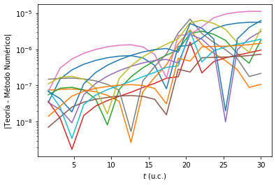

```python
error_rs=abs(rs-rs_teo)
error_vs=abs(vs-vs_teo)

import matplotlib.pyplot as plt
fig=plt.figure()
ax=fig.gca()

for i in range(2):
    for j in range(3):
        ax.plot(ts[1:],error_rs[i,1:,j],label="")
        ax.plot(ts[1:],error_vs[i,1:,j],label="")

#Decoración
ax.set_xlabel("$t$ (u.c.)")
ax.set_ylabel("|Teoría - Método Numérico|")
ax.set_yscale("log")
```

**Figura 7.95.** Comparación de las componentes calculadas del vector de estado de cada partícula en un sistema de dos cuerpos, obtenidas con la teoría desarrollada en este capítulo y con la solución numérica de alta precisión conseguida con métodos numéricos. Cada curva representa una componente ($x_1$, $y_1$, $z_1$, $v_{x1}$, etc.) Para no recargar más la figura se ha evitado inciar a que curva corresponde cada componente.

Como puede apreciarse en la Figura (code:error_teoria), la comparación entre las componentes del vector de estado calculado con la teoría y el obtenido con la solución numérica de la e.d.m., tiene dos características bastante notables:

1. La diferencia entre ambos es muy pequeño. Este resultado permite concluir que la teoría es capaz de predecir con gran precisión la posición y velocidad de las partículas, que es justamente lo que buscabamos.
2. La diferencia no es nula y al parecer crece con el tiempo. Este importante hecho, en lugar de revelar una limitación intrínseca de nuestros resultados analíticos, en realidad es prueba de la precisión limitada de los métodos numéricos utilizados para resolver la e.d.m. Adicionalmente, el hecho de que el error de estos métodos tenga una tendencia creciente con el tiempo, es una limitación bien conocida de los métodos numéricos aplicados en la solución de la e.d.m. de n cuerpos en mecánica celeste, un problema sobre el que volveremos en el [Capítulo *El formalismo hamiltoniano*].

Indice | Previo: Problema2Cuerpos.SolucionTiempo.AproximacionKepler | Siguiente: Problema2Cuerpos.SolucionTiempo.VariablesUniversales